# Viz wages

Duc-Quang Nguyen | swissinfo.ch

2017

## TODO

Integrate this [report](http://lenews.ch/2017/05/04/swiss-employees-the-best-paid-in-europe-according-to-study/)

salaire & age https://www.jobcloud.ch/c/fr-ch/blog/2014/09/barometre-salarial-apres-55-ans-les-augmentations-salaires-se-font-rares-cp/

https://www.forbes.com/sites/learnvest/2014/01/13/your-high-earning-years-salary-secrets-for-your-20s-30s-and-40s/#22ae1f01201e

## TXT

Money can’t buy everything. Still, salary might still be an important factor to consider when deciding of a career path. How different occupation differ We present here at the official European statistics on wages (Earnings Survey 2014)

Switzerland boasts among the highest earning in the world. According to an European survery on salary from 2014, with over 6000 € Swiss’ average salary expressed was the highest in Europe as illustrated in the graphic under. This represents more than twice EU-28 mean earnings, 14 times Bulgaria average wage. However expressing the wages in Euros, largely inflates Swiss salaries. Because of the strong Swiss franc, furthermore it doesn’t account for the high cost of living. Once standardiszed by purchasing power, Switzerland still tops of European average wage

https://datawrapper.dwcdn.net/z8s6D/1/

[interactive chart not shown]

### Wage by occupation

https://datawrapper.dwcdn.net/jP1tg/1/

[interactive chart not shown]

## Snippets

La théorie du capital humain montre que par un investissement continu durant la carrière, les compétences s’accroissent tout au long de la carrière professionnelle et cette expérience accumulée entraîne un salaire croissant dans une perspective de cycle de vie. C’est l’expérience et non l’âge en tant que tel qui est rémunérée.

https://www.jobcloud.ch/c/fr-ch/blog/2014/09/barometre-salarial-apres-55-ans-les-augmentations-salaires-se-font-rares-cp/

Disparities in gross hourly earnings within a country can be measured using deciles, and in particular the lowest and highest deciles, which correspond to the 10% of employees earning the least (D1) and to the 10% earning the most (D9). As a consequence, a high D9/D1 interdecile ratio indicates large disparities. D1 is the maximum gross hourly earnings received by the 10% of employees earnings least. D9 is the minimum gross hourly earnings received by the 10% of employees earning most.

```r
eu.dat$age <- factor(eu.dat$age, levels = c("Y_LT30", "Y30-39", "Y40-49", "Y50-59", "Y_GE60", "TOTAL"))
dd <- eu.dat %>% filter(indic_se == 'ERN_MN_PPS', nace_r2 == 'B-S_X_O', time == 2014) %>% select(-time, -nace_r2, -indic_se)

dd1 <- eu.dat %>% filter(indic_se %in% c('ERN_MN_EUR', 'ERN_MN_PPS', 'ERN_D1_PPS', 'ERN_D9_PPS'), !geo %in% c('EA18', 'EA19'),  age == "TOTAL", nace_r2 == 'B-S_X_O', isco08 == "TOTAL", age == "TOTAL", time == 2014)
dd1 %<>% spread(indic_se, values) %>% mutate(ratio = ERN_D9_PPS / ERN_D1_PPS) %>%
  select(-nace_r2, -isco08, -age, -time, -ERN_D9_PPS, -ERN_D1_PPS) %>%
  gather(indic_se, values, -geo)

#dd1 %>% mutate()
dd1$group <- ifelse(dd1$geo %in% eurostat::eu_countries[,1], 'EU',
       ifelse(dd1$geo %in% eurostat::eu_candidate_countries[,1], 'candidate EU',
              ifelse ( dd1$geo %in% eurostat::efta_countries[,1], 'EFTA', '')
       )
)
dd1 %<>% mutate(geo.label = countrycode(dd1$geo, "eurostat", "country.name")) %>% mutate(geo.label = ifelse(is.na(geo.label), as.character(geo), geo.label))
```

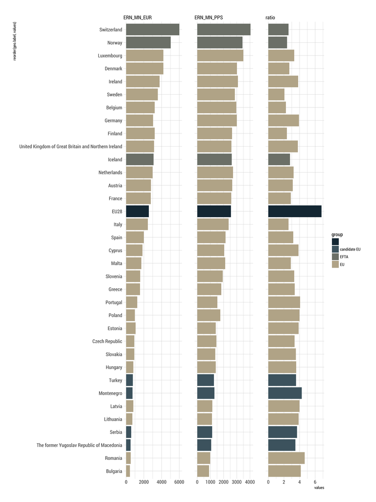

```r
ggplot(dd1) + geom_bar(aes(x = reorder(geo.label, values), y = values, group=group, fill = group), stat = "identity") + facet_wrap(~ indic_se, scales = "free_x") +
  coord_flip() + theme_ipsum_rc() + scale_fill_manual(values = swi_col)
```

```r
dd1.dw <- dd1 %>% select(-geo) %>% spread(indic_se, values) %>% select(2,1, 3:ncol(dd1))
write.csv(dd1.dw, file = "input/averageWage_DW.csv", row.names = F)
```

```r
#dd2 <- dd %>% group_by(geo, age) %>% mutate(tot.isco = values[which(isco08 == "TOTAL")]) %>% ungroup() %>% filter(isco08 != "TOTAL")
dd2 <- eu.dat %>% filter(indic_se %in% c('ERN_MN_PPS', 'ERN_MN_EUR'), nace_r2 == 'B-S_X_O', time == 2014) %>%
  select(-time, -nace_r2)  %>% spread(indic_se, values)

dd2 %<>% group_by(geo, age) %>% mutate(
  `tot.isco.eur` = ERN_MN_EUR[which(isco08 == "TOTAL")],
  val.eur = round((( ERN_MN_EUR - `tot.isco.eur`) / `tot.isco.eur`) * 100, 1),
  `tot.isco.pps` = ERN_MN_PPS[which(isco08 == "TOTAL")],
  val.pps = (( ERN_MN_PPS - `tot.isco.pps`) / `tot.isco.pps`) * 100
) %>% ungroup()
all.equal(dd2$val.eur, dd2$val.pps)
```

```
## [1] "Mean relative difference: 0.001387462"
```

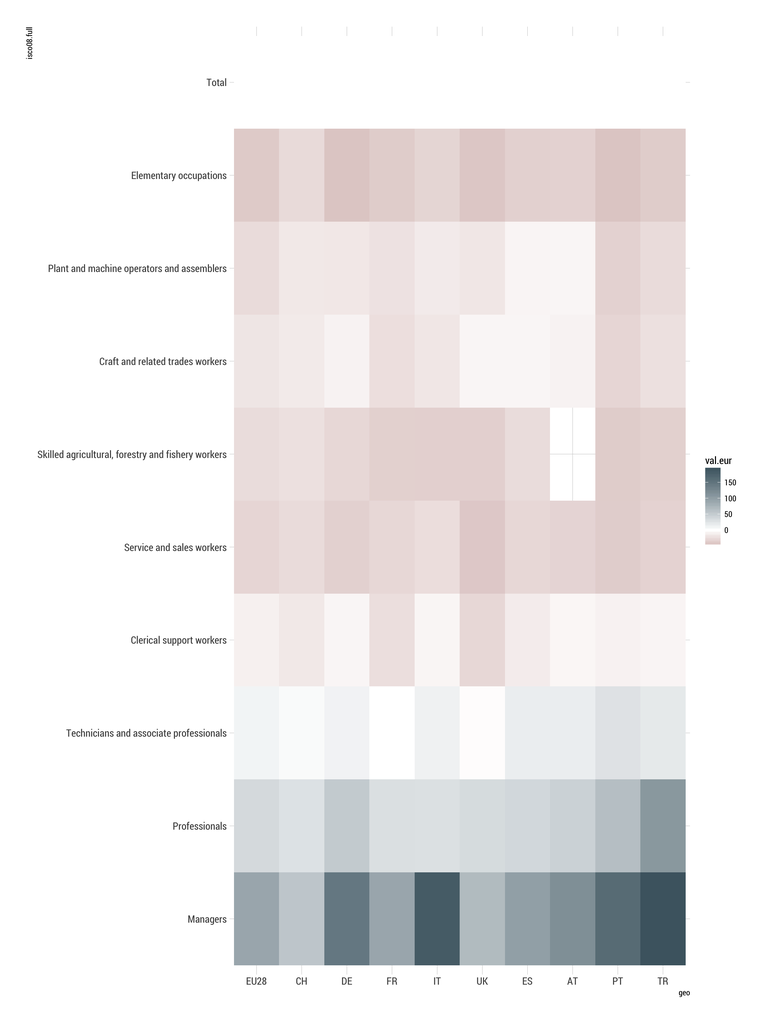

```r
dd2 %<>% select(-ERN_MN_PPS, -tot.isco.pps, -val.pps, -tot.isco.eur)


dd2 %<>% filter(geo %in% iso2.sub) %>% mutate(geo = factor(geo, levels = iso2.sub))
dd2$isco08.full <- factor(isco.dic[match(dd2$isco08, isco.dic$code_name), 2] %>% unlist(use.names = F),
                         levels = isco.dic[match(levels(dd2$isco08)[levels(dd2$isco08) %in% dd2$isco08], isco.dic$code_name), 2] %>%
                           unlist(use.names = F))

ggplot(dd2 %>% filter(age == "TOTAL")) + geom_tile(aes(x = geo, y = isco08.full, fill = val.eur)) + theme_ipsum_rc() +
  scale_fill_gradient2(high = "#4c6570", mid = , low = "#72302f", midpoint = 0)
```

```r
dd2a <- dd2 %>% filter(age == "TOTAL", isco08.full != "Total") %>% mutate(isco08.full = droplevels(isco08.full)) %>% mutate(geo = as.character(geo))
dd2a$geo[which(dd2a$geo == 'UK')] <- 'GB'

dd2a %<>% mutate(geo.label = countryTranslation(ifelse(nchar(dd2a$geo) == 2, dd2a$geo, NA), "EN")[,-1])
dd2a$geo.label <- ifelse(is.na(dd2a$geo.label), dd2a$geo, dd2a$geo.label)
dd2a$geo.label <- factor(dd2a$geo.label, levels = dd2a[match(gsub("UK", "GB", iso2.sub), dd2a$geo), "geo.label"] %>% unlist(use.names = F))


#dd2a %<>% mutate(geo.label = countrycode(geo, "iso2c", "country.name")) %>% mutate(geo.label = ifelse(is.na(geo.label), geo, geo.label))

dd2a$tooltip <- paste0(
    '<table cellpadding="1" style="line-height:0.9">',
    '<tr><td><strong>', dd2a$geo.label,'</strong></td></tr>',
    '<tr><td><i>', dd2a$isco08.full, '</i></td></tr>',
    '<tr><td>', "Average wage", ': <strong>', dd2a$ERN_MN_EUR, ' €</strong>', '</td></tr>',
    '<tr><td>', "% difference with country's average wage", ": <strong>", dd2a$val.eur, '%</strong></td></tr>',
    '</table>')

lang <- 'EN'
# make an interactive version
hc <- hchart(dd2a, "heatmap",
             hcaes(x = geo.label, y = isco08.full, value = val.eur, tooltip = tooltip)) %>%
  hc_chart(marginRight = 2) %>%
  hc_colorAxis( stops = list(list(0,  swi_col[length(swi_col)]), list(0.33, "white"), list(1, swi_col[1])),  min = -50, max = 100) %>%
  hc_legend(layout = "horizontal", verticalAlign = "top", width =  90, padding = 0,
            align = "center", valueDecimals = 0, x = -10, rtl = ifelse(lang == "AR", T, F),
            reversed = ifelse(lang == "AR", T, F)) %>%
  hc_add_theme(hc_theme_swi) %>%
  hc_yAxis(reversed = TRUE, offset = 2, tickLength = 0, lineWidth = 0,
           gridLineWidth = 0, minorGridLineWidth = 0,
           title = list(text = ""), labels = list(y = 4, style = list(fontSize = "12px")),
           opposite = ifelse(lang == "AR", T, F)) %>%
  hc_xAxis(lineWidth = 0, title = list(text = ""), reversed = ifelse(lang == "AR", T, F), opposite = TRUE) %>%
  hc_size(height = 530) %>%
  hc_tooltip(
    formatter = JS("function() { return this.point.tooltip;}"),
    useHTML = TRUE,
    borderWidth = 1,
    padding = 3
  )

hc
```

[interactive chart not shown]

```r
#footer <- paste0(txt['source', lang], ": ", txt['source.name', lang])

save_html(
  tags$html(
    tags$head(includeHTML(style_swi_highcharter())),
    tags$body(
     # tags$h2(txt['main.title', lang]),
     # div(class = "descr", HTML(txt['descr', lang])),
     # tags$h3(txt['h3', lang]),
      div(class="graphic", hc),
      #div(id = "cite", HTML(footer)),
      HTML(iframeresizer)
    )
  ), file = paste0("heatmap_wageByISCO08_", lang, ".html"), libdir = "js"
)
```

```r
dd3 <- eu.dat %>%
  filter(indic_se == 'ERN_MN_EUR', nace_r2 == 'B-S_X_O', time == 2014, geo %in% iso2.sub) %>%
  select(-time, -nace_r2, -indic_se)

dd4 <- dd3 %>% arrange(age) %>% group_by(isco08, geo) %>%
  mutate(diff = c(NA, (values[-1] - values[-c(length(values))] ) / values[-c(length(values))] )) %>%
  ungroup() %>%
  filter(!age %in% c('TOTAL', 'Y_LT30'))

dd4.p <- ggplot(dd4 %>% filter(isco08 != "TOTAL")) + geom_bar(aes(x = age, y = diff, fill = age), stat = "identity") +
  facet_grid(geo ~ isco08) + theme_ipsum_rc() +
  scale_fill_ipsum()


dd3 %<>% group_by(isco08, geo) %>% arrange(age) %>%
  mutate(wage.lt30 =  values[1]) %>% ungroup() %>%
  filter(age != "TOTAL")

dd3 %<>% mutate(val = (values - wage.lt30) / wage.lt30)

dd3$isco08.full <- factor(isco.dic[match(dd3$isco08, isco.dic$code_name), 2] %>%
  unlist(use.names = F), levels = isco.dic[match(levels(dd3$isco08), isco.dic$code_name), 2] %>% unlist(use.names = F))

## add colour, line size
dd3 %<>% mutate(color = names(iso2.sub)[match(geo, iso2.sub)], size = ifelse(geo %in% c('CH', 'EU28'), 0.5, 0.1))


# dd3.gp <- ggplot(dd3 %>% filter(isco08 != "TOTAL")) +
#   geom_line(aes(x = age, y = val, group = geo, colour = geo, size = size), alpha = 0.7) +
#   geom_point(aes(x = age, y = val, group = geo, colour = geo, size = size)) +
#   facet_wrap(~isco08.full, nrow = 3) + swi_theme() +
#   theme() +
#   scale_fill_gradient2(high = "#152c37", mid = "white", low = "#72302f", midpoint = 0) + geom_hline(yintercept = 0) +
#   scale_colour_ipsum() + scale_size_identity() + ggtitle("% difference in average wage by age and occupation groups") + ylim(c(0, 100))
#
# dd3.gp
#
# dd3i <- ggplot(dd3 %>% filter(isco08 != "TOTAL")) +
#   geom_line(aes(x = age, y = val, group = geo, colour = geo, size = size, data_id = interaction(age, geo, isco08.full)), alpha = 0.7) +
#   geom_point_interactive(aes(x = age, y = val, group = geo, colour = geo, size = size)) +
#   facet_wrap(~isco08.full, ncol = 2) + swi_theme() +
#     theme(
#       legend.position = "none",
#      # plot.background = element_rect(fill = "#333333", size = 0, color = NA),
#       panel.grid.major.y=element_line(color="#737373", linetype="dotted", size=0.09),
#      # axis.title = element_text(colour = "#f7f5ed", size = 15),
#       #axis.text = element_text(colour = "#e5dbcd"),
#       strip.background = element_blank(),
#       strip.text = element_blank(),
#       plot.margin=unit(c(0, 0.1, 0, 0.1), "cm")) +
#   scale_fill_gradient2(high = "#152c37", mid = "white", low = "#72302f", midpoint = 0) + geom_hline(yintercept = 0) +
#   scale_size_identity() + ylim(c(0, 100))
#
#
# ggiraph(code = {print(dd3i)})

lang <- 'FR'
oc <- "OC1"
charts <- lapply(unique(dd3$isco08)[unique(dd3$isco08) != "TOTAL"], function(oc) {

  ageGroup <-  c(">30 ans", "30-39", "40-49 ", "50-59", "<60 ans")

  # get different translations
  dddd <- dd3 %>% filter(isco08 == oc) %>% select(-wage.lt30) %>%
    filter(age != 'Y_LT30') %>%
    mutate(geo = ifelse(as.character(geo) == 'EU28', 'EU', as.character(geo)),
           geo = ifelse(as.character(geo) == 'UK', 'GB', geo)) %>%
    mutate(label = countryTranslation(geo, lang)[,2]) %>%
    # get age translation
    mutate(age = factor(age, labels = ageGroup[-1]))

  dddd$tip <- paste0(
    '<h4>', as.character(dddd$label), '</h4><div class="tpsubtitle">',
    as.character(dddd$isco08.full), '</div><div class = "tp">',
    "Salaire moyen des ", as.character(dddd$age), " comparé aux ", ageGroup[1],
    " :<b>", ifelse(dddd$val >0, "+", "-"), round(dddd$val, 2) * 100, "</b>%<br>",
    "Salaire moyen: ", dddd$values, '€</div>')
  dddd$tip <- gsub("'", "_", gsub("\\\n", "", dddd$tip))

  gp <- ggplot(dddd, aes(x = age, y = val, group = geo, colour = color)) +
  geom_line(aes(size = size + 0.1), alpha = 0.4) +
  geom_point_interactive(
    aes(size = size + 1.5, alpha = size + 0.1,
        data_id = interaction(age, geo, isco08.full), tooltip = tip)) +
  scale_size_identity() +
  scale_colour_identity() +
  scale_y_continuous(limits = c(0, 1), labels=percent, expand = c(0.01, 0), name = "") +
  scale_x_discrete( name = "", expand = c(0.02, 0.02))

  if(oc %in% c("OC1", "OC2")) {
    gp <- gp + geom_text(data = dddd %>% filter(geo %in% c('CH', 'EU'), age == ageGroup[length(ageGroup)]),
                   aes(label = label), hjust = 0.9)
  }

  gpl <- gp +  swi_theme(base_size = 12, base_family = "Open Sans Condensed", base_color = "#152c37") +
    theme(
      legend.position = "none",
     # plot.background = element_rect(fill = "#333333", size = 0, color = NA),
      panel.grid.major.y=element_line(color="#8c8c8c", size=0.02),
      axis.ticks.x = element_line(size = 1, colour = '#595959'),
      axis.text.y = element_text(margin=margin(r=-4)),
      axis.line.x = element_line(size=0.5),
     # axis.title = element_text(colour = "#f7f5ed", size = 15),
      #axis.text = element_text(colour = "#e5dbcd"),
      #plot.title=element_text(margin=margin(b=3)),
      #strip.background = element_blank(),
      #strip.text = element_blank(),
      plot.margin=unit(c(0.5, 0.6, .3, 0), "cm"))

  gpli <- ggiraph(code = {print(gpl)},
    hover_css = "fill-opacity:0.6;stroke-opacity:0.9;stroke-width:1.1px;stroke:#333333;",
    tooltip_opacity = 0.7,
    pointsize = 12,
    width = 1,
    width_svg = 3.7,
    height_svg = 3.3,
    fonts = list(sans = "Open Sans Condensed", serif = "Open Sans Condensed"))
    list(chart = gpli, title = as.character(unique(dddd$isco08.full)))
})
save_html(
   tags$html(
      tags$head(includeHTML("styles.html")),
  fluidPage(
    #tags$h2(txt["main.title", lang]),
    #div(class = "descr", HTML(paste0(txt["descr", lang], "<br>", txt["descr2", lang]))),
    #tags$h4(txt["h3", lang]),
    div(class="graphic",
        fluidRow(lapply(1:length(charts), function(i) {
          column(4, div(class = "graphic",  h4(HTML(charts[[i]]$title)), charts[[i]]$chart))
        }))#,
        #div(id = "cite", HTML(footer))
    ),
    HTML(iframeresizer)
  )), #background = "#EDEDED",
  file =  paste0("wageByISCOandAge_", lang, ".html"), libdir = "js")
```